# Analýza dopravní dostupnosti lokalit v rámci JMK hromadnou dopravou

Autoři: Zbyněk Pokora (projekt, kód, analýza, markdown), Jan Pelíšek (kód, analýza, prezentace), Marcel Svačina (prezentace)

**Manažerské shrnutí**

**Cíl**: Zmapovat pokrytí veřejnou dopravou v Jihomoravském kraji, identifikovat oblasti s nízkou dostupností a zjistit oblasti, ze kterých je možná doprava IDS za 60 minut a méně do lokality Brno-střed.

- Analýza dostupnosti veřejné dopravy do centra Brna z obcí Jihomoravského kraje odhalila významné rozdíly v cestovních časech.
- Z celkem 1284 vstupních bodů ve vstupních datech bylo nalezeno adekvátní spojení hromadnou dopravou pro 887 z nich. Z této množiny o 887 vstupních bodech je pro 67 bodů (lokalit) dosažitelná cílová destinace Brno-střed do 60 minut. Brno-centrum do 60 minut, veřejnou dopravou od 6:45 s časovým oknem 45 minut, ve všední den.
- Nejkratší cestovní časy byly zaznamenány v obcích v okrese Brno-venkov, zatímco nejdelší v oblastech např. Hevlín, Velké Pavlovice, Chvalkovice na Hané nebo Ostrov u Macochy. Překvapivým zjištěním je například oblast Břeclavska nebo Skalice nad Svitavou
- Vizuální prezentace dostupnosti na mapě ukazuje koncentraci dobře dostupných oblastí v blízkosti Brna a podél hlavních dopravních koridorů. Například oblast Břeclavska (Pohansko) je překvapivě velmi dobře dostupná oproti lokalitám ležícím mezi ní a Brnem. Oblasti s horší dostupností se nacházejí zejména na okrajích kraje, v oblastech s řidším spojením. V takových oblastech nebyly nalezeny vhodné trasy s časem pod 120 min.
- Detailní tabulky obcí s nejlepší a nejhorší dostupností jsou uvedeny níže pro další přehled.

**Omezení**:

Je nutné vzít v potaz, že analýza je vytvořena pouze pro jeden konkrétní den a konkrétní čas. Tento aspekt může způsobovat, že některé lokality nebyly zahrnuty ve výstupu z důvodu nedostupnosti dopravního spojení ve zvoleném časovém okně. Pro vytvoření komplexního modelu vytvořit celou sérii výpočtů pro různé časy a období. Pro takto komplexní analýzu v tomto projektu nebyly dostupné dostatečné zdroje.

# Příprava prostředí

Zahrnuje kontrolu a instalaci potřebných softwarových komponent a knihoven.

- **Kontrola a instalace JDK:** Balíček r5py, který používáme pro výpočty tras, vyžaduje specifickou verzi Javy. Tento kód zajišťuje, že je nainstalována správná verze.
- **Kontrola a instalace Python balíčků:** Pro analýzu a vizualizaci dat jsou nezbytné různé Python knihovny (osmnx, r5py, geopandas, atd.). Tento kód zkontroluje jejich přítomnost a případně je nainstaluje.
- **Import knihoven:** Po zajištění všech závislostí importujeme potřebné knihovny pro další použití v zápisníku.

```python
import subprocess
import re


# Kontrola verze JDK. Balíček r5py vyžaduje novější verzi JAVA, proto může být nutný update.
def ensure_jdk(min_major=21):
    """
    Zkontroluje, jestli je nainstalovaná Java ≥ min_major.
    Pokud ne, stáhne a nainstaluje Temurin JDK min_major.
    """
    # 1) Verze (stávající) Javy
    try:
        out = subprocess.check_output(['java', '-version'], stderr=subprocess.STDOUT)
        txt = out.decode()
        m = re.search(r'version "(?P<ver>\d+)', txt)
        current = int(m.group('ver')) if m else 0
    except Exception:
        current = 0

    # 2) Porovnánís požadovanou verzí
    if current < min_major:
        print(f"Detekována Java {current}, potřebuji alespoň {min_major}. Instaluji JDK {min_major}…")
        cmds = [
            "apt-get update -qq",
            "apt-get install -y wget tar",
            f"wget -q https://github.com/adoptium/temurin{min_major}-binaries/releases/download/jdk-{min_major}+35/"
            f"OpenJDK{min_major}U-jdk_x64_linux_hotspot_{min_major}_35.tar.gz -O openjdk{min_major}.tar.gz",
            f"mkdir -p /usr/lib/jvm/java-{min_major}",
            f"tar -xzf openjdk{min_major}.tar.gz -C /usr/lib/jvm/java-{min_major} --strip-components=1",
            f"update-alternatives --install /usr/bin/java java /usr/lib/jvm/java-{min_major}/bin/java 1",
            f"update-alternatives --install /usr/bin/javac javac /usr/lib/jvm/java-{min_major}/bin/javac 1",
            f"update-alternatives --set java /usr/lib/jvm/java-{min_major}/bin/java",
            f"update-alternatives --set javac /usr/lib/jvm/java-{min_major}/bin/javac"
        ]
        for cmd in cmds:
            print(f">>> {cmd}")
            subprocess.run(cmd, shell=True, check=True)
        # ověření
        print(subprocess.check_output(['java', '-version'], stderr=subprocess.STDOUT).decode())
    else:
        print(f"Java je ve verzi {current}, což vyhovuje (≥ {min_major}).")

ensure_jdk(21)
```

```
Detekována Java 11, potřebuji alespoň 21. Instaluji JDK 21…
>>> apt-get update -qq
>>> apt-get install -y wget tar
>>> wget -q https://github.com/adoptium/temurin21-binaries/releases/download/jdk-21+35/OpenJDK21U-jdk_x64_linux_hotspot_21_35.tar.gz -O openjdk21.tar.gz
>>> mkdir -p /usr/lib/jvm/java-21
>>> tar -xzf openjdk21.tar.gz -C /usr/lib/jvm/java-21 --strip-components=1
>>> update-alternatives --install /usr/bin/java java /usr/lib/jvm/java-21/bin/java 1
>>> update-alternatives --install /usr/bin/javac javac /usr/lib/jvm/java-21/bin/javac 1
>>> update-alternatives --set java /usr/lib/jvm/java-21/bin/java
>>> update-alternatives --set javac /usr/lib/jvm/java-21/bin/javac
openjdk version "21" 2023-09-19 LTS
OpenJDK Runtime Environment Temurin-21+35 (build 21+35-LTS)
OpenJDK 64-Bit Server VM Temurin-21+35 (build 21+35-LTS, mixed mode, sharing)
```

```python
# Kontrola požadovaných balíčků a jejich případná instalace pokud nejsou nalezeny
import importlib.util
import sys

packages = ['osmnx', 'r5py', 'geopandas', 'matplotlib', 'pandas', 'shapely',
            'folium', 'osm2geojson', 'mapclassify', "contextily", "nbconvert",
            "openpyxl", "numba"]

def install_package(package):
    subprocess.check_call([sys.executable, "-m", "pip", "install", package])

for package in packages:
    if importlib.util.find_spec(package) is None:
        print(f"Balíček {package} nebyl nalezen. Instaluji...")
        install_package(package)
    else:
        print(f"Balíček {package} je již nainstalován.")
```

```
Balíček osmnx nebyl nalezen. Instaluji...
Balíček r5py nebyl nalezen. Instaluji...
Balíček geopandas je již nainstalován.
Balíček matplotlib je již nainstalován.
Balíček pandas je již nainstalován.
Balíček shapely je již nainstalován.
Balíček folium nebyl nalezen. Instaluji...
Balíček osm2geojson nebyl nalezen. Instaluji...
Balíček mapclassify nebyl nalezen. Instaluji...
Balíček contextily nebyl nalezen. Instaluji...
Balíček nbconvert je již nainstalován.
Balíček openpyxl nebyl nalezen. Instaluji...
Balíček numba je již nainstalován.
```

```python
# import knihoven
import geopandas as gpd # práce s geospatial daty
import matplotlib.pyplot as plt # vizualizace
import osmnx as ox # práce s  Openstreetmap daty
import osm2geojson # práce s Openstreetmap daty
import pandas as pd # data manipulation a analýza
import r5py # raptor routing engine - časy a trasy
from shapely.geometry import Polygon, shape, Point # práce s polygony
import folium # interaktivní mapy
import contextily as ctx # basemaps
import requests # interakce s webovými službami a API
import nbconvert # konverze Jupiter notebooku do html, pdf apod.
import openpyxl # export do exelu
import numba
from google.colab import data_table
data_table.disable_dataframe_formatter()
```

# Geografické vymezení úlohy

Pro správné provedení analýzy je nezbytné geograficky vymezit studovanou oblast a připravit potřebná geografická data.

- **Načtení hranic Jihomoravského kraje a jednotlivých okresů:** Pro definování studované oblasti a filtrování dat načítáme administrativní hranice Jihomoravského kraje a jeho okresů z geoboundaries.org.
- **Příprava pro počáteční body:** Jako počáteční body pro výpočet cestovních časů používáme centroidy základních sídelních jednotek. Tato data jsou filtrována na oblast Jihomoravského kraje **a následně přichycena k nejbližším budovám** pro realističtější simulaci začátku cesty využitím prostorové indexace algorithem R-tree.
- **Příprava pro cílovou destinaci - Brno-střed:** Cílovou destinací naší analýzy je oblast Brno-střed, konkrétně vybrané klíčové **přestupní uzly** v rámci této městské části. Načítáme geoprostorová data pro tuto městskou část a zastávky MHD, abychom mohli cílovou oblast vizuálně i analyticky vymezit a identifikovat cílové body pro výpočty.

```python
# API pro ADM2 v ČR (okresy).
api_url_okr = "https://www.geoboundaries.org/api/current/gbOpen/CZE/ADM2"
hranice_okr = requests.get(api_url_okr)
len(hranice_okr.json())

# Všechny okresy ČR, kontrola názvů
okresy = gpd.read_file(hranice_okr.json()['gjDownloadURL'])
display(okresy.head())
print(okresy["shapeName"].unique())
```

|  | shapeName | shapeISO | shapeID | shapeGroup | shapeType | geometry |
| --- | --- | --- | --- | --- | --- | --- |
| 0 | Nový Jičín |  | 57006924B81305487356227 | CZE | ADM2 | POLYGON ((18.04966 49.80866, 18.04867 49.80073... |
| 1 | Cheb |  | 57006924B74936445485800 | CZE | ADM2 | POLYGON ((12.38127 50.28779, 12.37307 50.28735... |
| 2 | Sokolov |  | 57006924B20358302460191 | CZE | ADM2 | POLYGON ((12.82103 50.04788, 12.82059 50.05541... |
| 3 | Karlovy Vary |  | 57006924B50757157558324 | CZE | ADM2 | POLYGON ((12.9561 49.9789, 12.95588 49.98081, ... |
| 4 | Chomutov |  | 57006924B32669310027153 | CZE | ADM2 | POLYGON ((13.25622 50.23573, 13.25958 50.23615... |

```
['Nový Jičín' 'Cheb' 'Sokolov' 'Karlovy Vary' 'Chomutov' 'Most' 'Teplice'
 'Ústí nad Labem' 'Děčín' 'Louny' 'Litoměřice' 'Česká Lípa' 'Liberec'
 'Jablonec nad Nisou' 'Semily' 'Trutnov' 'Náchod' 'Tachov' 'Domažlice'
 'Plzeň-North' 'Rakovnik' 'Klatovy' 'Plzeň-South' 'Plzeň-City' 'Rokycany'
 'Kladno' 'Mělník' 'Mladá Boleslav' 'Jičín' 'Hradec Králové'
 'Rychnov nad Kněžnou' 'Pardubice' 'Chrudim' 'Ústí nad Orlicí' 'Jeseník'
 'Nymburk' 'Kolín' 'Beroun' 'Prague-East' 'Prague' 'Prague-West' 'Benešov'
 'Příbram' 'Kutná Hora' 'České Budějovice' 'Písek' 'Prachatice'
 'Strakonice' 'Český Krumlov' 'Jindřichův Hradec' 'Tábor' 'Třebíč'
 'Pelhřimov' 'Havlíčkův Brod' 'Žďár nad Sázavou' 'Jihlava' 'Vsetín'
 'Uherské Hradiště' 'Kroměříž' 'Zlín' 'Brno-Country' 'Svitavy' 'Hodonín'
 'Znojmo' 'Břeclav' 'Blansko' 'Vyškov' 'Brno-City' 'Prostějov' 'Přerov'
 'Olomouc' 'Bruntál' 'Šumperk' 'Opava' 'Karviná' 'Frýdek-Místek'
 'Ostrava-City']
```

```python
jhm_okresy = ['Hodonín','Brno-Country','Znojmo', 'Břeclav', 'Blansko',
              'Vyškov', 'Brno-City']

jhm_okresy_gdf = okresy[okresy["shapeName"].isin(jhm_okresy)]
print(f"Počet okresů: {len(jhm_okresy_gdf)}") # 7 okresů!
print(jhm_okresy_gdf.crs)
```

```
Počet okresů: 7
EPSG:4326
```

```python
# API pro ADM1 v ČR (kraj).
api_url_kraj = "https://www.geoboundaries.org/api/current/gbOpen/CZE/ADM1"
hranice_kraj = requests.get(api_url_kraj)
len(hranice_kraj.json())

# Všechny okresy ČR, kontrola názvů
kraje = gpd.read_file(hranice_kraj.json()['gjDownloadURL'])
jmk = kraje[kraje["shapeName"] == "Jihomoravský kraj"]
print(jmk)

jmk_union = jmk.unary_union
```

```
            shapeName shapeISO                  shapeID shapeGroup shapeType  \
10  Jihomoravský kraj    CZ-64  73172107B81289681513643        CZE      ADM1

                                             geometry
10  POLYGON ((15.54243 48.90774, 15.54349 48.90751...
```

```python
!pip install gdown
import gdown
file_id = "131v21t4yieXWoKU6deeRFB1N1PJKgXh6"
url = f"https://drive.google.com/uc?id={file_id}"
gdown.download(url, "zsj.zip", quiet=False)
!unzip zsj.zip -d "/content/Data_DAMI"
```

```
Downloading...
From (original): https://drive.google.com/uc?id=131v21t4yieXWoKU6deeRFB1N1PJKgXh6
From (redirected): https://drive.google.com/uc?id=131v21t4yieXWoKU6deeRFB1N1PJKgXh6&confirm=t&uuid=8a7e1b9b-2cc1-4580-a1ec-901df73f958e
To: /content/zsj.zip
```

```
OpenJDK VM warning: the use of signal() and sigset() for signal chaining was deprecated in version 16.0 and will be removed in a future release. Use sigaction() instead.
Archive:  zsj.zip
  inflating: /content/Data_DAMI/SPH_ZSJ.cpg
  inflating: /content/Data_DAMI/SPH_ZSJ.shx
  inflating: /content/Data_DAMI/SPH_ZSJ.dbf
  inflating: /content/Data_DAMI/SPH_ZSJ.shp
```

```python
# --- Příprava pro počáteční body ----
brno_mesto_poly = (
    jhm_okresy_gdf
    .loc[jhm_okresy_gdf['shapeName'] == 'Brno-City', 'geometry']
    .unary_union
)


# 1) Načtení ZSJ shapefile - uložen na vašem Google Disku v /content/Data_DAMI
gdf_zsj = gpd.read_file('/content/Data_DAMI/SPH_ZSJ.shp')
gdf_zsj.head()
if gdf_zsj.crs is None:
  gdf_zsj.crs = 'epsg:5514'

gdf_zsj.to_crs(epsg=4326, inplace=True)

gdf_zsj_jmk = gdf_zsj[gdf_zsj.geometry.within(jmk.unary_union)]

gdf_zsj_jmk = gpd.clip(gdf_zsj, jmk)

gdf_zsj_jmk = gdf_zsj_jmk[~gdf_zsj_jmk.geometry.intersects(brno_mesto_poly)]
print(len(gdf_zsj_jmk))
```

```
1426
```

```python
mestske_casti = gpd.read_file(
    "https://raw.githubusercontent.com/JanPelisek/dostupnost-JMK/main/Data_sources/m_casti_brno.geojson"
    )

# 3) Filtrace pro Brno-střed
brno_stred = mestske_casti[mestske_casti["nazev"] == "Brno-střed"]

print("Filtr Brno-střed, počet záznamů:", len(brno_stred))
print(brno_stred.head())

# 4) Kontrola a případná transformace do stejného CRS jako 'jhm_okresy_gdf'
#    Pokud jhm_okresy_gdf má jiný CRS, např. EPSG:5514 a brno_stred EPSG:4326, je třeba sjednotit.
if brno_stred.crs != jhm_okresy_gdf.crs:
    brno_stred = brno_stred.to_crs(jhm_okresy_gdf.crs)
```

```
Filtr Brno-střed, počet záznamů: 1
       kod       nazev             datum_exportu  ObjectId   Shape__Area  \
15  550973  Brno-střed 2024-09-14 00:00:00+00:00        16  3.425288e+07

    Shape__Length                                           geometry
15   32238.997112  POLYGON ((16.59367 49.21105, 16.59369 49.21099...
```

```python
# Načtení zastávek
# Slouží pouze k vizualizaci
zastavky_mhd = gpd.read_file(
    "https://raw.githubusercontent.com/JanPelisek/dostupnost-JMK/main/Data_sources/stops_3349896397534691836.geojson"
    )

# Kontrolní výpis CRS systému
print("CRS zastávek MHD:", zastavky_mhd.crs)
print("CRS Jihomoravského kraje:", jhm_okresy_gdf.crs)
```

```
CRS zastávek MHD: EPSG:4326
CRS Jihomoravského kraje: EPSG:4326
```

**Vizualizace všech možných zastávek v rámci systému IDS JMK.**

Z grafu je čitelné, že určitý počet zastávek IDS JMK se nachází nejenom v sousedních jrajích, ale i v zahraničí. Konrétně příhraniční oblasti Rakouska a na Slovensku

Zastávky zasahující za hranici kraje budou vynechány. Mezi řešené lokality také není zahrnut okres Brno-město.

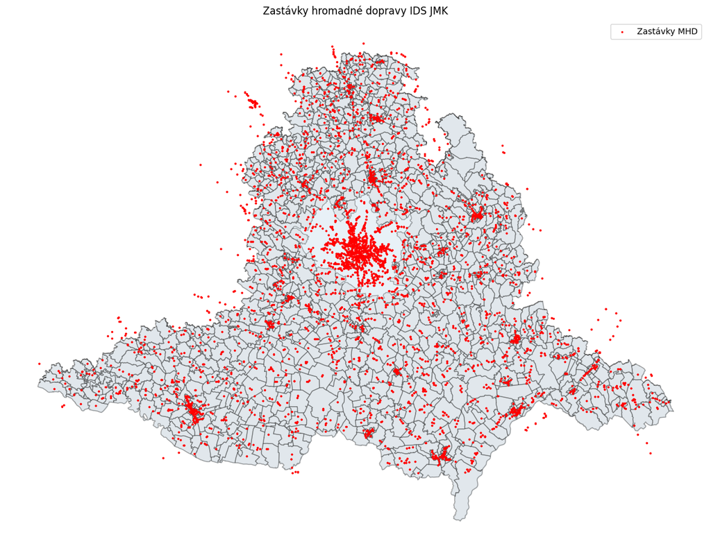

```python
# Graf zastávek v systému - komplet
fig, ax = plt.subplots(figsize=(15, 13))

# Hranice JMK
jmk.plot(
    ax=ax,
    edgecolor="black",
    alpha=0.1,
    label="Jihomoravský kraj"
)

gdf_zsj_jmk.plot(
    ax=ax,
    color="lightgrey",
    edgecolor = "black",
    alpha=0.3,
    label="ZSJ"
)

# Brno-střed
brno_stred.plot(
    ax=ax,
    color="white",
    edgecolor="darkred",
    alpha=0.7,
    label="Brno-střed"
)
# Zastávky MHD
zastavky_mhd.plot(
    ax=ax,
    marker="o",
    color="red",
    markersize=2,
    label="Zastávky MHD"
)

ax.set_title("Zastávky hromadné dopravy IDS JMK")
ax.set_axis_off()
plt.legend()
plt.show()
```

```python
# --- FILTRACE ZASTÁVEK UVNITŘ JMK ---

# 1) Jsou CRS zastávek i polygonu kraje jsou stejné?
zastavky_mhd = zastavky_mhd.to_crs(jmk.crs)

# 2) Sjednotíme polygon JMK do jednoho MultiPolygonu
jmk_union = jmk.unary_union

# 3) Zastávky uvnitř kraje
zastavky_jmk = zastavky_mhd[zastavky_mhd.geometry.intersects(jmk_union)]

# 4) Zastávky mimo kraj
zastavky_mimo_jmk = zastavky_mhd[~zastavky_mhd.index.isin(zastavky_jmk.index)]

# 5) Rychlý přehled
print(f"Zastávek celkem: {len(zastavky_mhd)}")
print(f"– v kraji: {len(zastavky_jmk)}")
print(f"– mimo kraj: {len(zastavky_mimo_jmk)}")



# 6) Tabulka zastávek mimo JMK
zastavky_mimo_jmk.head()
```

```
Zastávek celkem: 10817
– v kraji: 10164
– mimo kraj: 653
```

|  | stop_id | stop_name | latitude | longitude | zone_id | location_type | parent_station | wheelchair_boarding | platform_code | ObjectId | GlobalID | geometry |
| --- | --- | --- | --- | --- | --- | --- | --- | --- | --- | --- | --- | --- |
| 265 | U15829Z1 | Laa an der Thaya, Stadtplatz | 48.720393 | 16.384622 | 580.0 | 0 | U15829N35 | 2\ | NaN | 266 | d8522f2c-876e-4a6e-ae88-30e3643be2e8 | POINT (16.38462 48.72039) |
| 268 | U15838Z1 | Laa an der Thaya, Bahnhof | 48.722881 | 16.402679 | 580.0 | 0 | U15838N36 | 2\ | NaN | 269 | c6bd5ac8-7897-453c-b2a8-c8583de9dc18 | POINT (16.40268 48.72288) |
| 271 | U15839Z1 | Laa an der Thaya, Therme | 48.723047 | 16.395582 | 580.0 | 0 | U15839N37 | 2\ | NaN | 272 | ac2b0632-bab9-44c6-9d4e-234f6d425a3d | POINT (16.39558 48.72305) |
| 274 | U15839Z2 | Laa an der Thaya, Therme | 48.723047 | 16.395582 | 580.0 | 0 | U15839N37 | 2\ | NaN | 275 | f9765e02-a164-4d2a-840c-5730b972969b | POINT (16.39558 48.72305) |
| 277 | U15838Z2 | Laa an der Thaya, Bahnhof | 48.723331 | 16.402208 | 580.0 | 0 | U15838N36 | 2\ | NaN | 278 | eb5eb35c-0b21-451f-a81d-098968496be3 | POINT (16.40221 48.72333) |

```python
# --- FILTRACE STARTOVACÍCH ZASTÁVEK MIMO OKRES BRNO-MĚSTO ---

#  Filtr: zastávky v JMK, které nejsou uvnitř Brno‑město
start_zastavky = zastavky_jmk[~zastavky_jmk.geometry.intersects(brno_mesto_poly)]

# 3) Kontrola výsledku
print(f"Celkem zastávek v JMK: {len(zastavky_jmk)}")
print(f"Startovacích zastávek mimo Brno‑město: {len(start_zastavky)}")

# 4) Náhled
start_zastavky.head()
```

```
Celkem zastávek v JMK: 10164
Startovacích zastávek mimo Brno‑město: 8232
```

|  | stop_id | stop_name | latitude | longitude | zone_id | location_type | parent_station | wheelchair_boarding | platform_code | ObjectId | GlobalID | geometry |
| --- | --- | --- | --- | --- | --- | --- | --- | --- | --- | --- | --- | --- |
| 2 | U19012Z1 | Hodonín, STS | 48.870733 | 17.116435 | 900.0 | 0 | U19012N147 | 2\ | NaN | 3 | 8e763c9c-41a7-406b-b129-1f9ce1bbf764 | POINT (17.11644 48.87073) |
| 5 | U19002Z1 | Hodonín, Brněnská | 48.862476 | 17.118758 | 900.0 | 0 | U19002N146 | 2\ | NaN | 6 | c3a4f5c0-26d6-4661-90e7-daa437f04cd5 | POINT (17.11876 48.86248) |
| 7 | U15775Z2 | Hevlín, škola | 48.751285 | 16.380187 | 570.0 | 0 | U15775N4 | 2\ | NaN | 8 | 9fd43094-867d-487f-8b9a-21b37775b978 | POINT (16.38019 48.75128) |
| 9 | U16348Z1 | Klobouky u Brna, samoobsluha | 48.995079 | 16.867518 | 640.0 | 0 | U16348N160 | 2\ | NaN | 10 | 809a9be4-3411-4a2f-9dda-085e2cebd7f0 | POINT (16.86752 48.99508) |
| 10 | U15773Z2 | Hevlín, cihelna | 48.761387 | 16.383460 | 570.0 | 0 | U15773N5 | 2\ | NaN | 11 | e6cabbf5-a676-4d14-afbd-8d0c7482d76d | POINT (16.38346 48.76139) |

# Příprava a validace datových podkladů pro analýzu počátečních lokalit

V rámci analytického procesu je nezbytné precizně definovat a připravit **datové podklady reprezentující počáteční lokality**, ze kterých budou následně počítány cestovní časy do cílové destinace. Tento krok zahrnuje systematický postup zajišťující relevanci a přesnost vstupních dat:

- **Akce 1: Načtení dat základních sídelních jednotek (ZSJ).** Data o základních sídelních jednotkách (ZSJ) slouží jako primární geografický rámec pro definování studovaných počátečních oblastí. Z tohoto důvodu je nezbytné načíst odpovídající shapefile obsahující geometrie ZSJ na území Jihomoravského kraje.
- **Akce 2: Geometrická transformace a výpočet centroidů.** Pro každou identifikovanou ZSJ je proveden výpočet jejího geometrického centroidu. Tyto centroidy představují prvotní bodovou reprezentaci počátečních lokalit, která slouží jako základ pro další zpřesnění.
- **Akce 3: Prostorové zpřesnění - přichycení k nejbližším budovám.** S cílem zvýšit realističnost modelu cestování jsou vypočtené centroidy prostorově zpřesněny. Tento proces zahrnuje identifikaci a "přichycení" každého centroidu k nejbližší stavební struktuře (budově) na základě dat z OpenStreetMap. Implementace prostorového indexu (R-tree) optimalizuje efektivitu vyhledávání nejbližších budov.
- **Akce 4: Geografická filtrace datových bodů.** V zájmu zachování analytické relevance jsou výsledné datové body podrobeny geografické filtraci. Tento krok zajišťuje, že do další fáze analýzy vstupují pouze body situované v rámci administrativních hranic Jihomoravského kraje a současně vylučuje body nacházející se na území okresu Brno-město, který není předmětem této studie.
- **Akce 5: Vizualizace pro validaci datových podkladů.** Pro vizuální validaci a kontrolu prostorového rozložení připravených počátečních bodů je provedena jejich grafická prezentace na mapě. Tato vizualizace zahrnuje zobrazení bodů ve spojení s administrativními hranicemi Jihomoravského kraje a definovanou cílovou oblastí Brno-střed. Vizuální inspekce umožňuje ověřit, zda distribuce bodů koresponduje s geografickým vymezením studované oblasti a zda proces zpřesnění přinesl očekávané výsledky.

Sumarizací uvedených kroků je zajištěna kvalitativně vyšší úroveň připravenosti vstupních dat, což je esenciální pro robustní a validní výsledky následné analýzy dostupnosti.

```python
# Počáteční body
start_places = gdf_zsj_jmk[["ID", "GEO", "geometry"]].copy()

start_places = start_places[start_places.geometry.type.isin(["Polygon", "Multipolygon"])]
start_places["geometry"] = start_places["geometry"].centroid

start_places = start_places.to_crs(epsg=4326)

start_places = start_places.rename(columns={"ID": "id", "GEO": "name"}).reset_index(drop=True)
start_places["id"] = start_places['id'].astype(int)
start_places = start_places[~start_places.geometry.intersects(brno_mesto_poly)]
print(len(start_places))
start_places.head()
```

```
1298
```

|  | id | name | geometry |
| --- | --- | --- | --- |
| 0 | 13722 | Pohansko | POINT (16.91243 48.71413) |
| 1 | 176672 | Boří dvůr | POINT (16.7983 48.71951) |
| 2 | 304107 | Boří les | POINT (16.84669 48.72508) |
| 3 | 126365 | Štěpnice | POINT (16.88188 48.74291) |
| 4 | 176699 | Valtice | POINT (16.77442 48.7453) |

```python
# <buildings> shape files
file_id = "1CFjohVqCgwSyu4NO95xumg1UHI0owmEL"
url = f"https://drive.google.com/uc?id={file_id}"
gdown.download(url, "buildings_shp.zip", quiet=False)
!unzip buildings_shp.zip -d "/content/Data_DAMI"
```

```
Downloading...
From (original): https://drive.google.com/uc?id=1CFjohVqCgwSyu4NO95xumg1UHI0owmEL
From (redirected): https://drive.google.com/uc?id=1CFjohVqCgwSyu4NO95xumg1UHI0owmEL&confirm=t&uuid=65809d3f-b7c2-4562-b7a4-f4422ff908c5
To: /content/buildings_shp.zip
```

```
OpenJDK VM warning: the use of signal() and sigset() for signal chaining was deprecated in version 16.0 and will be removed in a future release. Use sigaction() instead.
Archive:  buildings_shp.zip
 extracting: /content/Data_DAMI/gis_osm_buildings_a_free_1.cpg
  inflating: /content/Data_DAMI/gis_osm_buildings_a_free_1.dbf
  inflating: /content/Data_DAMI/gis_osm_buildings_a_free_1.prj
  inflating: /content/Data_DAMI/gis_osm_buildings_a_free_1.shp
  inflating: /content/Data_DAMI/gis_osm_buildings_a_free_1.shx
```

```python
# subroutine pro snaping centridů k nejbližší budově - použijí se indexy z R-tree
from rtree import index
from shapely.ops import nearest_points

def snap_to_buildings_rtree(pt, spatial_index, geom_lookup, k=5):
    """
    Přichycení bodu k nejbližší budově pomocí rtree.

    Parametry:
    - pt: shapely.geometry.Point
    - spatial_index: rtree.index.Index
    - geom_lookup: seznam shapely geometrií
    - k: počet kandidátů ke kontrole

    Návrat:
    - shapely.geometry.Point
    """
    # Získání indexů kandidátů
    candidate_idxs = list(spatial_index.nearest(pt.bounds, k))

    # Najdi nejbližší bod z kandidátů
    min_dist = float('inf')
    best_snap = None

    for i in candidate_idxs:
        geom = geom_lookup[i]
        _, nearest = nearest_points(pt, geom)
        dist = pt.distance(nearest)
        if dist < min_dist:
            min_dist = dist
            best_snap = nearest

    return best_snap
```

```python
buildings = gpd.read_file('/content/Data_DAMI/gis_osm_buildings_a_free_1.shp')
buildings = buildings[buildings.geometry.notnull()]
```

```python
print(buildings.head(1))
print(buildings["type"].unique())
```

```
    osm_id  code    fclass              name  type  \
0  4019771  1500  building  Metropole Zličín  mall

                                            geometry
0  POLYGON ((14.2841 50.05319, 14.28432 50.05321,...
['mall' 'school' 'retail' 'barn' 'civic' None 'commercial' 'residential'
 'transportation' 'university' 'apartments' 'garage' 'industrial' 'house'
 'service' 'church' 'kindergarten' 'train_station' 'office' 'hotel'
 'dormitory' 'chapel' 'warehouse' 'college' 'synagogue' 'government'
 'hangar' 'sports_centre' 'sports_hall' 'pavilion' 'protected_area'
 'supermarket' 'hospital' 'no' 'roof' 'cabin' 'farm_auxiliary' 'reservoir'
 'public' 'forestry' 'greenhouse' 'terrace' 'manufacture' 'castle'
 'cathedral' 'ruins' 'detached' 'restaurant' 'monastery' 'parking'
 'garages' 'hut' 'funeral_hall' 'shed' 'demolished' 'stadium' 'station'
 'gatehouse' 'construction' 'semidetached_house' 'guardhouse' 'kiosk'
 'water_tower' 'bridge' 'stable' 'temple' 'fire_station' 'roundhouse'
 'toilets' 'transformer_tower' 'basilica' 'carport' 'allotment_house'
 'bungalow' 'bunker' 'religious' 'storage_tank' 'grandstand' 'museum'
 'tower' 'cuzk:ruian' 'riding_hall' 'farm' 'collapsed' 'presbytery'
 'mosque' 'multipurpose' 'tent' 'townhall' 'abandoned' 'cowshed' 'silo'
 'production_hall' 'wood_kiln' 'brewery' 'wayside_shrine' 'clinic'
 'kingdom_hall' 'outbuilding' 'pub' 'shelter' 'administrative' 'shrine'
 'bakehouse' 'police' 'container' 'power_tower' 'houseboat' 'boathouse'
 'sty' 'cultural' 'flat' 'glasshouse' 'historic' 'education' 'château'
 'watermill' 'gazebo' 'gasometer' 'ger' 'electricity' 'ship' 'bell_tower'
 'windmill' 'wayside_chapel' 'chicken_coop' 'disused' 'destroyed' 'reta'
 'warehouse;yes' 'chimney' 'hall' 'basin' 'static_caravan' 'guardhous'
 'bank' 'guest_house' 'library' 'pumping_station' 'tank' 'transformer'
 'data_center' 'digester' 'pillar' 'ruin' 'wine_cellar' 'stands'
 'staircase' 'wine_press_house' 'proposed' 'shop' 'removed' 'slurry_tank'
 'chalet' 'livestock' 'balcony' 'containers' 'railway_carriage'
 'conservatory' 'overgrown' 'tech_cab' 'hayrack' 'elevator' 'stage'
 'vapenka_vitoul' 'food_stand' 'pergola']
```

```python
# omezení budov na objekty jenž je možné předpokládat v zastavěných oblastech
building_type = ['mall', 'school', 'retail', 'civic', 'commercial', 'residential',
 'university', 'apartments', 'house', 'church', 'kindergarten',
 'train_station', 'office', 'hotel', 'dormitory', 'chapel', 'college',
 'synagogue', 'government', 'sports_centre', 'sports_hall', 'pavilion',
 'supermarket', 'hospital', 'restaurant',
 'kiosk', 'fire_station', 'toilets', 'museum', 'townhall', 'clinic',
 'pub', 'police', 'library', 'shop', 'bank']

buildings = buildings[buildings["type"].isin(building_type)]
```

```python
# Příprava prostorového RTree indexu pro <buildings>
spatial_index = index.Index()

# abychom si zachovali přístup k původnímu GeoDataFrame
geom_lookup = []

for idx, geom in enumerate(buildings.geometry):
    spatial_index.insert(idx, geom.bounds)
    geom_lookup.append(geom)
```

```python
# počáteční body snepnuté subrutinou snap_tu_buildings_rtree
starting_points = start_places.copy()
starting_points['geometry'] = starting_points.geometry.apply(
    lambda pt: snap_to_buildings_rtree(pt, spatial_index, geom_lookup))

print(f"Proměnná <starting_points> obsahuje počet záznamů: {len(starting_points)}")
print(starting_points.info())
print(starting_points.crs)
starting_points.head()
```

```
Proměnná <starting_points> obsahuje počet záznamů: 1298
<class 'geopandas.geodataframe.GeoDataFrame'>
RangeIndex: 1298 entries, 0 to 1297
Data columns (total 3 columns):
 #   Column    Non-Null Count  Dtype
---  ------    --------------  -----
 0   id        1298 non-null   int64
 1   name      1298 non-null   object
 2   geometry  1298 non-null   geometry
dtypes: geometry(1), int64(1), object(1)
memory usage: 30.6+ KB
None
EPSG:4326
```

|  | id | name | geometry |
| --- | --- | --- | --- |
| 0 | 13722 | Pohansko | POINT (16.92353 48.74548) |
| 1 | 176672 | Boří dvůr | POINT (16.80024 48.7218) |
| 2 | 304107 | Boří les | POINT (16.85408 48.73304) |
| 3 | 126365 | Štěpnice | POINT (16.88241 48.75041) |
| 4 | 176699 | Valtice | POINT (16.77336 48.74732) |

```python
# omezení pouze na JMK
starting_points = starting_points[starting_points.geometry.within(jmk_union)]
```

```python
print(f"Počet bodu: {starting_points.count()}")
print(len(starting_points["id"].unique()))
```

```
Počet bodu: id          1284
name        1284
geometry    1284
dtype: int64
1284
```

```python
fig, ax = plt.subplots(figsize=(15, 13))

# Hranice JMK
jmk.plot(
    ax = ax,
    color = "lightgrey",
    edgecolor = "black",
    alpha = 0.1,
    label="Jihomoravský kraj"
)

# Brno-střed
brno_stred.plot(
    ax = ax,
    color = "white",
    edgecolor = "darkred",
    alpha = 0.5,
    label = "Brno-střed"
)

gdf_zsj_jmk.plot(
    ax=ax,
    color = "lightgrey",
    edgecolor = "black",
    alpha=0.4,
    label = "Obce"
)

# Počáteční body
starting_points.plot(
    ax = ax,
    marker = "o",
    color = "red",
    markersize = 5,
    label = "Počáteční body"
)

ctx.add_basemap(
    ax,
    source=ctx.providers.OpenStreetMap.Mapnik,
    crs=starting_points.crs.to_string()
)

ax.set_title("Počáteční body")
ax.set_axis_off()
plt.show()
```

```
Output hidden; open in https://colab.research.google.com to view.
```

# Definice a příprava cílových destinací pro analýzu dostupnosti

Pro účely kvantifikace dopravní dostupnosti veřejnou dopravou je nezbytné precizně vymezit **cílovou destinaci**, do které bude kalkulován cestovní čas. V této analýze byla jako klíčová cílová oblast identifikována městská část **Brno-střed**. Příprava datových podkladů pro cílovou destinaci zahrnuje následující kroky:

- **Identifikace klíčových přestupních uzlů.** V rámci městské části Brno-střed byly pro simulaci cílového bodu vybrány stěžejní přestupní uzly městské hromadné dopravy (MHD) a regionální veřejné dopravy. Tyto uzly reprezentují významné body v dopravní síti s vysokou konektivitou a slouží jako reprezentativní cílové lokality pro výpočet dostupnosti.
- **Geoprostorové vymezení cílové oblasti.** Načteno a zpracováno je geoprostorové data definující administrativní hranici městské části Brno-střed. Tento polygonální podklad slouží k prostorovému filtru a vizuálnímu kontextu cílové destinace v rámci celkové analýzy.
- **Filtrace zastávek MHD v cílové oblasti.** Z celkového souboru zastávek MHD v Jihomoravském kraji jsou vybrány pouze ty zastávky, které se nachází v geoprostorovém vymezení městské části Brno-střed. Z této množiny jsou dále selektovány zastávky odpovídající předem definovaným klíčovým přestupním uzlům. Tím je zajištěna relevance cílových bodů pro analýzu dopravní dostupnosti.
- **Vizualizace cílových zastávek.** Vybrané cílové zastávky jsou vizualizovány na mapě, překryté přes polygon městské části Brno-střed. Tato vizualizace umožňuje ověřit správné umístění cílových bodů a poskytuje grafické znázornění analyzované cílové oblasti v kontextu dopravní sítě.

Precizní definice a příprava cílové destinace, reprezentované klíčovými přestupními uzly v Brně-středu, tvoří esenciální základ pro následné výpočty cestovních časů a analýzu dostupnosti veřejnou dopravou v rámci Jihomoravského kraje.

```python
# --- FILTRACE CÍLOVÝCH ZASTÁVEK V OKRUHU BRNO-STŘED ---
# polygon Brno-střed
target_area = brno_stred.unary_union

# Filtrace: zastávky, které leží uvnitř
brno_stred_zastavky = zastavky_jmk[zastavky_jmk.geometry.intersects(target_area)]

# Filtrace na přestupní uzly
prestupni_uzly = ['Autobusové nádraží', 'Zvonařka', 'ÚAN Zvonařka', 'Hlavní nádraží', 'Křídlovická', 'Malinovského náměstí', 'Mendlovo náměstí', 'Moravské náměstí', 'Česká', 'Pisárky', 'Ústřední hřbitov','Heršpická', 'Úvoz', 'Tvrdého', 'Úzká','Výstaviště - hlavní vstup', ]

target_zastavky = brno_stred_zastavky.loc[brno_stred_zastavky['stop_name'].isin(prestupni_uzly)]

# Kontrola výsledků
print(f"Cílových stanic v Brno-střed: {len(target_zastavky['stop_name'].unique())}\n")
print(f"Seznam zastavek: \n\n{target_zastavky['stop_name'].sort_values().unique()}\n")
```

```
Cílových stanic v Brno-střed: 16

Seznam zastavek:

['Autobusové nádraží' 'Heršpická' 'Hlavní nádraží' 'Křídlovická'
 'Malinovského náměstí' 'Mendlovo náměstí' 'Moravské náměstí' 'Pisárky'
 'Tvrdého' 'Výstaviště - hlavní vstup' 'Zvonařka' 'ÚAN Zvonařka'
 'Ústřední hřbitov' 'Úvoz' 'Úzká' 'Česká']
```

**Vizualizace cílových stanic.**

Cílové zastávky jsou definovány hlavními přestupními uzly IDS JMK v oblasti Brno-střed:

Autobusové nádraží, Heršpická, Hlavní nádraží, Křídlovická, Malinovského náměstí, Mendlovo náměstí, Moravské náměstí, Pisárky, Tvrdého, Výstaviště - hlavní vstup, Zvonařka, ÚAN Zvonařka, Ústřední hřbitov, Úvoz, Úzká, Česká.

[figure not shown]

```python
# Převod na Web Mercator
brno_wm = brno_stred.to_crs(epsg=3857)
target_wm = target_zastavky.to_crs(epsg=3857)

# Vykreslení
fig, ax = plt.subplots(figsize=(14, 12))
brno_wm.plot(
    ax=ax,
    color='white',
    edgecolor='darkred',
    alpha=0.6,
    label='Brno-střed'
)
target_wm.plot(
    ax=ax,
    marker='^',
    color='red',
    markersize=30,
    label='Cílové zastávky MHD - Brno-střed'
)

# Přidání basemap (např. OSM Mapnik)
ctx.add_basemap(
    ax,
    source=ctx.providers.OpenStreetMap.Mapnik,
    crs=target_wm.crs.to_string()
)

ax.set_title('Zastávky hromadné dopravy IDS JMK - cílové body')
ax.set_axis_off()
plt.show()
```

# Výpočet tras

V této klíčové části notebooku probíhá samotný výpočet cestovních časů z definovaných počátečních bodů do cílových přestupních uzlů v Brno-střed.

- **Stažení potřebných dat:** Pro vytvoření transportní sítě pro výpočty jsou použita data OpenStreetMap ve formátu PBF a jízdní řády veřejné dopravy (GTFS).
- **Vytvoření transportní sítě:** Pomocí algoritmu Raptor (r5py) bude vytvořena dopravní síť, která kombinuje silniční síť z OSM a jízdní řády z GTFS. Tato síť umožňuje simulovat cestování různými druhy dopravy, včetně chůze, jízdy na kole a veřejné dopravy.
- **Výpočet matice cestovních časů:** Výpočet matice cestovních časů z každého počátečního bodu do každého cílového přestupního uzlu v Brno-střed. Výpočet probíhá pro definovaný čas odjezdu (6:45) a časové okno (45 minut), což zohledňuje reálné jízdní řády.
- **Zpracování a agregace výsledků:** Vypočítané cestovní časy jsou agregovány pro každý počáteční bod (medián), aby se získala reprezentativní hodnota dostupnosti pro danou lokalitu.
- **Vizualizace a analýza výsledků:** Výsledné cestovní časy jsou vizualizovány na mapě a analyzovány (pomocí histogramu, heatmapy a kategorií dostupnosti) pro identifikaci oblastí s různou úrovní dostupnosti.

```python
## stažení GTFS dat - soubor se uloží lokálně v /content na vašem disku Google
# GTFS pro 1. polovinu 2024. z učebních materiálů. S nejnovější verzí nefungovaly výpočty.
!wget -O improved-gtfs-ids-jmk.zip "https://raw.githubusercontent.com/JanPelisek/dostupnost-JMK/main/Data_sources/improved-gtfs-ids-jmk.zip"
```

```
OpenJDK VM warning: the use of signal() and sigset() for signal chaining was deprecated in version 16.0 and will be removed in a future release. Use sigaction() instead.
--2025-05-25 07:48:17--  https://raw.githubusercontent.com/JanPelisek/dostupnost-JMK/main/Data_sources/improved-gtfs-ids-jmk.zip
Resolving raw.githubusercontent.com (raw.githubusercontent.com)... 185.199.108.133, 185.199.109.133, 185.199.110.133, ...
Connecting to raw.githubusercontent.com (raw.githubusercontent.com)|185.199.108.133|:443... connected.
HTTP request sent, awaiting response... 200 OK
Length: 5732295 (5.5M) [application/zip]
Saving to: ‘improved-gtfs-ids-jmk.zip’

improved-gtfs-ids-j 100%[===================>]   5.47M  --.-KB/s    in 0.09s

2025-05-25 07:48:18 (63.2 MB/s) - ‘improved-gtfs-ids-jmk.zip’ saved [5732295/5732295]
```

```python
# stažení OSM.PBF - soubor se uloží lokálně v /content na vašem disku Google
# Nezbytné pro vytvoření dopvní sítě
!wget -O czech_republic.osm.pbf "https://download.geofabrik.de/europe/czech-republic-latest.osm.pbf"
```

```
OpenJDK VM warning: the use of signal() and sigset() for signal chaining was deprecated in version 16.0 and will be removed in a future release. Use sigaction() instead.
--2025-05-25 07:48:18--  https://download.geofabrik.de/europe/czech-republic-latest.osm.pbf
Resolving download.geofabrik.de (download.geofabrik.de)... 95.217.45.61, 95.217.63.98, 95.216.245.233, ...
Connecting to download.geofabrik.de (download.geofabrik.de)|95.217.45.61|:443... connected.
HTTP request sent, awaiting response... 200 OK
Length: 889486834 (848M) [application/octet-stream]
Saving to: ‘czech_republic.osm.pbf’

czech_republic.osm. 100%[===================>] 848.28M  19.4MB/s    in 45s

2025-05-25 07:49:04 (18.7 MB/s) - ‘czech_republic.osm.pbf’ saved [889486834/889486834]
```

```python
# Příprava vstupních (obcí) pro výpočty cestovních časů
origins = starting_points[["id", "geometry"]].copy()

print(len(origins))
origins.head()
```

```
1284
```

|  | id | geometry |
| --- | --- | --- |
| 0 | 13722 | POINT (16.92353 48.74548) |
| 1 | 176672 | POINT (16.80024 48.7218) |
| 2 | 304107 | POINT (16.85408 48.73304) |
| 3 | 126365 | POINT (16.88241 48.75041) |
| 4 | 176699 | POINT (16.77336 48.74732) |

Interaktivní vizualizace počátečních (výchozích) bodů a jednotlivých zastávek heomadné dopravy v systému IDS JMK. Zde je možné si ověřit, zda jsou výchozí body adekvátně umístěny.

Optimalizované umístění je oproti použití centroidu základní sídelní jednotky významně kvalitnější.

```python
stred = [49.195061, 16.606836]

# základ folium mapy s podkladem
m = folium.Map(
    location=stred,
    zoom_start=8,
    tiles="OpenStreetMap",
    attr="OpenStreetMap"
)

# vrstvy administrativních hranic a vstupní / výstupní body
brno_stred.explore(
    m=m,
    color="red",
    edgecolor="darkred",
    alpha=0.2,
    name="Brno‑střed - cílová destinace"
)

# počáteční body pro routovaní
origins.explore(
    m=m,
    marker_type='marker',
    marker_kwds={'radius': 3, 'fill': False, 'fillOpacity': 0.7},
    name='Start'
)

start_zastavky.explore(
    m=m,
    marker_type='circle_marker',
    marker_kwds={'radius': 3, 'color': 'purple', 'fill': True, 'fillOpacity': 0.7},
    name='Start – MHD'
)

folium.LayerControl().add_to(m)

# Zobrazení mapy
m
```

```
Output hidden; open in https://colab.research.google.com to view.
```

```python
output_file = "starting_points.html"
m.save(output_file)
```

```python
# Příprava koncových bodů (Zastávky v Brno-střed)
destinations = target_zastavky.rename(columns={'stop_id':'id'})[['id','geometry']]
```

```python
# Kontrola vstupnich a koncovych bodu
print(origins.crs, destinations.crs)
print(origins.head(), len(origins))
print(destinations.head(), len (destinations))
```

```
EPSG:4326 EPSG:4326
       id                   geometry
0   13722  POINT (16.92353 48.74548)
1  176672   POINT (16.80024 48.7218)
2  304107  POINT (16.85408 48.73304)
3  126365  POINT (16.88241 48.75041)
4  176699  POINT (16.77336 48.74732) 1284
          id                   geometry
1    U1011Z2  POINT (16.61762 49.18642)
3   U1146Z33  POINT (16.61362 49.19185)
4   U1146Z31  POINT (16.61399 49.19182)
8   U1696Z12  POINT (16.61615 49.18536)
13  U1696Z15  POINT (16.61757 49.18548) 131
```

```python
print(len(destinations['id'].unique()))
```

```
131
```

**Výpočet cestovních časů a analýza dostupnosti**

V této klíčové fázi analýzy probíhá vlastní výpočet cestovních časů z definovaných počátečních lokalit do vymezené cílové destinace v Brně-středu. Tento proces zahrnuje:

- **Příprava datových podkladů.** Pro vytvoření komplexní dopravní sítě, která reflektuje jak silniční infrastrukturu, tak i jízdní řády veřejné dopravy, jsou použity **OpenStreetMap (OSM) data** ve formátu PBF a **jízdní řády veřejné dopravy (GTFS)**. Tyto datové soubory jsou nezbytné pro modelování multimodálního cestování.
- **Vytvoření transportní sítě.** S využitím specializovaného algoritmu (**Raptor implementovaný v knihovně r5py**) je sestavena **transportní síť**. Tato síť integruje informace z OSM a GTFS, čímž umožňuje simulovat cestování různými druhy dopravy, včetně chůze, jízdy na kole a veřejné dopravy (autobusy, vlaky, tramvaje apod.). Vytvoření této sítě je komplexní proces, který může trvat delší dobu.
- **Výpočet matice cestovních časů.** Následně je proveden **výpočet matice cestovních časů**. Tato matice obsahuje informace o délce cesty z každého definovaného počátečního bodu do každého cílového přestupního uzlu v Brně-středu. Výpočet je proveden pro specifický čas odjezdu a definované časové okno, což umožňuje zohlednit reálné jízdní řády a proměnlivost dopravní situace.
- **Zpracování a agregace výsledků.** Vypočítané cestovní časy jsou dále zpracovány. Pro každý počáteční bod je typicky agregována reprezentativní hodnota cestovního času (např. medián), která sumarizuje dostupnost dané lokality do cílové oblasti. Tím je získána přehledná sada dat pro další analýzu a vizualizaci.
- **Analýza a vizualizace dostupnosti.** Získané výsledky (mediánové cestovní časy) jsou analyzovány a vizualizovány (např. pomocí histogramů, heatmap nebo kategorizovaných map). Tato fáze umožňuje identifikovat oblasti s různou úrovní dostupnosti, detekovat regionální disparity a prezentovat klíčové závěry analýzy.

Tento systematický proces, od přípravy datových podkladů až po vizualizaci výsledků, poskytuje robustní základ pro pochopení prostorového rozložení dostupnosti veřejnou dopravou v Jihomoravském kraji do jeho hlavního centra.

```python
# Vytvoření <transport_network> s potvrzení nebo chybovou hláškou na konci
# může běžet až 2 hodiny
try:
    transport_network = r5py.TransportNetwork(
        "/content/czech_republic.osm.pbf",  # povinný objekt, pro výpočty při jízdě autem (transpot mode CAR)
        ["/content/improved-gtfs-ids-jmk.zip"], # volitelný, umožňuje trasy MHD
        allow_errors=False
    )
    print("TransportNetwork vytvořen úspěšně:", transport_network)
except Exception as e:
    print("Chyba při vytváření TransportNetwork:", e)
```

```
TransportNetwork vytvořen úspěšně: <r5py.r5.transport_network.TransportNetwork object at 0x7fab13183190>
```

```python
# Definice výpočtu: počítají se všechny možné spoje z počátečního bodu, které lze najít v čase
# určeného oknem - zde 45 min. - po minutě. Výsledná hodnota pro danný bod je medián všech vyrůtovaných
# spojení v minutách. Maximální čas cesty je nastaven na 120 min. Nad tuto hranici je výpočet Null
import datetime

travel_time_prac_den = r5py.TravelTimeMatrix(
    transport_network,
    origins = origins,
    destinations = destinations,
    departure = datetime.datetime(2024,5,15,6,45),
    departure_time_window = datetime.timedelta(seconds = 2700),
    transport_modes = [r5py.TransportMode.TRANSIT],
    access_modes = [r5py.TransportMode.WALK],
    snap_to_network = True
)
```

```python
print(f"Počet záznamů: {len(travel_time_prac_den)}")
display(travel_time_prac_den.head())
travel_time_prac_den.info()
```

```
Počet záznamů: 168204
```

|  | from_id | to_id | travel_time |
| --- | --- | --- | --- |
| 0 | 13722 | U1011Z2 | 72.0 |
| 1 | 13722 | U1146Z33 | 65.0 |
| 2 | 13722 | U1146Z31 | 65.0 |
| 3 | 13722 | U1696Z12 | 74.0 |
| 4 | 13722 | U1696Z15 | 72.0 |

```
<class 'r5py.r5.travel_time_matrix.TravelTimeMatrix'>
RangeIndex: 168204 entries, 0 to 168203
Data columns (total 3 columns):
 #   Column       Non-Null Count   Dtype
---  ------       --------------   -----
 0   from_id      168204 non-null  int64
 1   to_id        168204 non-null  object
 2   travel_time  97789 non-null   float64
dtypes: float64(1), int64(1), object(1)
memory usage: 3.9+ MB
```

```python
time_matrix_prac_den = gdf_zsj_jmk.merge(travel_time_prac_den, left_on='ID',
                                         right_on = "from_id")
```

```python
time_matrix_prac_den = time_matrix_prac_den.merge(
    target_zastavky[['stop_id', 'stop_name']],
    left_on='to_id', right_on='stop_id', how='left')

time_matrix_prac_den.info()
```

```
<class 'geopandas.geodataframe.GeoDataFrame'>
RangeIndex: 168204 entries, 0 to 168203
Data columns (total 11 columns):
 #   Column       Non-Null Count   Dtype
---  ------       --------------   -----
 0   ID           168204 non-null  float64
 1   KOD_ZSJ      168204 non-null  int64
 2   GEO          168204 non-null  object
 3   KOD_LAU2     168204 non-null  float64
 4   KOD_KATUZE   168204 non-null  float64
 5   geometry     168204 non-null  geometry
 6   from_id      168204 non-null  int64
 7   to_id        168204 non-null  object
 8   travel_time  97789 non-null   float64
 9   stop_id      168204 non-null  object
 10  stop_name    168204 non-null  object
dtypes: float64(4), geometry(1), int64(2), object(4)
memory usage: 14.1+ MB
```

```python
# agregace časů podle počátečního bodu, medián
median_cesta_prac_den = time_matrix_prac_den.copy().groupby("from_id").median("travel_time")
median_cesta_prac_den = median_cesta_prac_den.reset_index()

display(median_cesta_prac_den.head())
print(f"Počet Non-Null záznamů mediánu cestovního času: {(median_cesta_prac_den['travel_time'].count())}")
```

|  | from_id | ID | KOD_ZSJ | KOD_LAU2 | KOD_KATUZE | travel_time |
| --- | --- | --- | --- | --- | --- | --- |
| 0 | 43 | 43.0 | 43.0 | 581291.0 | 600041.0 | 73.0 |
| 1 | 400 | 400.0 | 400.0 | 586030.0 | 600407.0 | NaN |
| 2 | 698 | 698.0 | 698.0 | 582794.0 | 600695.0 | 73.0 |
| 3 | 701 | 701.0 | 701.0 | 582808.0 | 600709.0 | 82.0 |
| 4 | 825 | 825.0 | 825.0 | 581372.0 | 600822.0 | 118.0 |

```
Počet Non-Null záznamů mediánu cestovního času: 887
```

```python
# vytvoření geopandas dataframu pro další vizualizaci, analýzu
median_cesta_prac_den = gpd.GeoDataFrame(
    median_cesta_prac_den,
    geometry=time_matrix_prac_den.groupby("from_id")['geometry'].first().values
    )
median_cesta_prac_den["obec"] = time_matrix_prac_den.groupby("from_id")['GEO'].first().values

median_cesta_prac_den = median_cesta_prac_den[['ID', "obec", "travel_time", "geometry"]]
median_cesta_prac_den = median_cesta_prac_den.rename(columns={'ID': 'id'})


data_table.disable_dataframe_formatter()
display(median_cesta_prac_den.head())

# kontrola počtu záznamů - chybějící znamenají, že nešlo routovat žádnout cestu
print(f"Počet záznamů: {len(median_cesta_prac_den)}")
print(f"Počet Non-Null záznamů mediánu cestovního času: {(median_cesta_prac_den['travel_time'].count())}")
```

|  | id | obec | travel_time | geometry |
| --- | --- | --- | --- | --- |
| 0 | 43.0 | Adamov-střed | 73.0 | POLYGON ((16.6568 49.30467, 16.65737 49.30433,... |
| 1 | 400.0 | Archlebov | NaN | POLYGON ((16.98737 49.02234, 16.98736 49.02239... |
| 2 | 698.0 | Babice nad Svitavou | 73.0 | POLYGON ((16.66734 49.28499, 16.66737 49.28503... |
| 3 | 701.0 | Babice u Rosic | 82.0 | POLYGON ((16.35721 49.18445, 16.35697 49.18428... |
| 4 | 825.0 | Bačov | 118.0 | POLYGON ((16.64866 49.5276, 16.64848 49.52721,... |

```
Počet záznamů: 1284
Počet Non-Null záznamů mediánu cestovního času: 887
```

```python
median_cesta_prac_den.info()
```

```
<class 'geopandas.geodataframe.GeoDataFrame'>
RangeIndex: 1284 entries, 0 to 1283
Data columns (total 4 columns):
 #   Column       Non-Null Count  Dtype
---  ------       --------------  -----
 0   id           1284 non-null   float64
 1   obec         1284 non-null   object
 2   travel_time  887 non-null    float64
 3   geometry     1284 non-null   geometry
dtypes: float64(2), geometry(1), object(1)
memory usage: 40.3+ KB
```

Histogram vizualizuje rozdělení mediánových cestovních časů z počátečních bodů v Jihomoravském kraji (kromě Brna-města) do cílových přestupních uzlů v Brně-středu.

Osa X (vodorovná): Reprezentuje medián cestovního času v minutách. Rozdělení osy na sloupce (bins) ukazuje intervaly cestovních časů.

Osa Y (svislá): Ukazuje počet počátečních bodů (základních sídelních jednotek), které spadají do daného časového intervalu na ose X. Vyšší sloupec značí více lokalit s mediánem cestovního času v daném rozmezí.

Sloupce: Výška každého sloupce odpovídá frekvenci (počtu počátečních bodů) pro daný interval cestovního času.

Křivka: Znázorňuje odhad hustoty rozdělení dat. Poskytuje plynulejší pohled na tvar distribuce mediánových cestovních časů.

Počty pozorování s časem cesty do 60 minut nejsou zastoupeny v distribuci nijak významě. Jednotlivé lokality budou kategorizovány podle mediánu cestovního času. Poměr zasstoupení je analyzován níže.

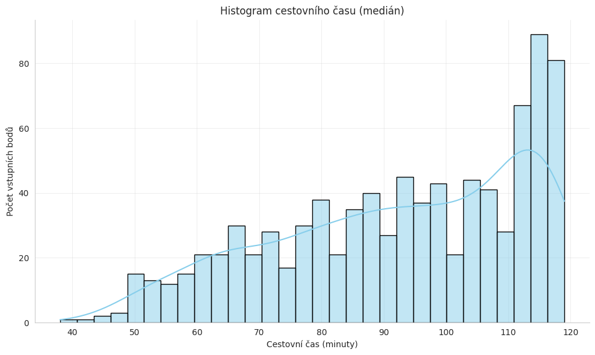

```python
import seaborn as sns

# Histogram
sns.set_style("whitegrid")

fig, ax = plt.subplots(figsize=(10, 6))
sns.histplot(median_cesta_prac_den["travel_time"], bins=30, kde=True,
             color="skyblue", edgecolor="black", ax=ax)


ax.set_title("Histogram cestovního času (medián)")
ax.set_xlabel("Cestovní čas (minuty)")
ax.set_ylabel("Počet vstupních bodů")
ax.grid(True, alpha = 0.3)
sns.despine()

plt.tight_layout()
plt.show()
```

**Vizualazace vypočtených časů**

Interaktivní heatmapa dostupnosti vizualizuje mediánové cestovní časy veřejnou dopravou z počátečních bodů v Jihomoravském kraji (kromě Brna-města) do cílových přestupních uzlů v Brně-středu.

Barevná škála: Barva indikuje délku cestovního času. Typicky světlejší odstíny reprezentují kratší časy (lepší dostupnost) a tmavší odstíny delší časy (horší dostupnost)

**Oblasti s dobrou dostupností:**

Oblasti s nejkratšími cestovními časy se budou jevit ve světlejších odstínech. Tyto oblasti se nejčastěji nacházejí blíže k Brnu a mají hustší nebo rychlejší spojení.

**Oblasti s horší dostupností:**

Oblasti s nejdelšími cestovními časy se zobrazí v tmavších odstínech. Tyto oblasti jsou často dále od Brna, mají méně častá spojení nebo vyžadují složitější přestupy.

**Vzory dostupnosti:**

Lze pozorovat, zda dostupnost klesá postupně s rostoucí vzdáleností od Brna, nebo zda existují specifické "kapsy" s dobrou/špatnou dostupností ovlivněné například hlavními dopravními koridory.

Černá oblast znázorňuje lokality pro které se nepovedlo vypočítat žádný spoj. Samostatná vizulizace níže.

```python
# --- Interaktivni vystup ---
from folium.plugins import MarkerCluster

# střed mapy (např. průměrnou pozici vašich dat)
stred = [
    median_cesta_prac_den.geometry.centroid.y.mean(),
    median_cesta_prac_den.geometry.centroid.x.mean()
]

# základ folium mapy s podkladem
m = folium.Map(
    location=stred,
    zoom_start=7,
    tiles="OpenStreetMap",
    attr="OpenStreetMap"
)

# vrstvy administrativních hranic
brno_stred.explore(
    m=m,
    color="red",
    edgecolor="darkred",
    alpha=0.5,
    name="Brno‑střed - cílová destinace"
)

# choropleth mřížka cestovních časů
median_cesta_prac_den.explore(
    m=m,
    column="travel_time",
    cmap="Reds",
    legend=True,
    name="Cestovní čas (medián)",
    tooltip=True     # umožní zobrazit hodnotu travel_time po najetí myší
)
# ovládání vrstev
folium.LayerControl(collapsed=False).add_to(m)

# Uložení mapy do HTML souboru
output_file = "main_heatmap.html"
m.save(output_file)

# Zobrazení mapy
m
```

```
Output hidden; open in https://colab.research.google.com to view.
```

```python
# export nevyrůtovaných lokalit (možnosti: chbyjící bod, přesah nad 120 min nebo více jak 8 přestupů)
not_routed = gpd.GeoDataFrame(
    median_cesta_prac_den,
    geometry=median_cesta_prac_den.geometry)

not_routed = not_routed[not_routed["travel_time"].isnull()]
not_routed = not_routed.reset_index(drop=True)

not_routed["id"] = not_routed["id"].astype(int)

not_routed = not_routed.merge(
    gdf_zsj_jmk,
    left_on="id",
    right_on="ID",
    how="left"
)

print(not_routed.info())
```

```
<class 'geopandas.geodataframe.GeoDataFrame'>
RangeIndex: 397 entries, 0 to 396
Data columns (total 10 columns):
 #   Column       Non-Null Count  Dtype
---  ------       --------------  -----
 0   id           397 non-null    int64
 1   obec         397 non-null    object
 2   travel_time  0 non-null      float64
 3   geometry_x   397 non-null    geometry
 4   ID           397 non-null    float64
 5   KOD_ZSJ      397 non-null    int64
 6   GEO          397 non-null    object
 7   KOD_LAU2     397 non-null    float64
 8   KOD_KATUZE   397 non-null    float64
 9   geometry_y   397 non-null    geometry
dtypes: float64(4), geometry(2), int64(2), object(2)
memory usage: 31.1+ KB
None
```

```python
not_routed = not_routed[["ID", "obec", "geometry_y"]]
not_routed = not_routed.rename(columns={"geometry_y": "geometry"})
not_routed.info()
```

```
<class 'geopandas.geodataframe.GeoDataFrame'>
RangeIndex: 397 entries, 0 to 396
Data columns (total 3 columns):
 #   Column    Non-Null Count  Dtype
---  ------    --------------  -----
 0   ID        397 non-null    float64
 1   obec      397 non-null    object
 2   geometry  397 non-null    geometry
dtypes: float64(1), geometry(1), object(1)
memory usage: 9.4+ KB
```

```python
not_routed.to_excel("not_routed.xlsx")
```

Vizualizace oblastí, pro které nebyly ve zvoleném čase vypočteny žádné dostupné spojení do cílové destinace Brno-střed. Seznam těchto lokalit je uložen v souboru not_routed.xslx.

```python
fig, ax = plt.subplots(figsize=(15, 13))

# Hranice JMK
jmk.plot(
    ax = ax,
    color = "lightgrey",
    edgecolor = "black",
    alpha = 0.3
)

not_routed.plot(
    ax=ax,
    color="purple",
    edgecolor="white",
    alpha=0.8
)

ctx.add_basemap(
    ax,
    source=ctx.providers.OpenStreetMap.Mapnik,
    crs=not_routed.crs.to_string()
)

ax.set_axis_off()
```

```
Output hidden; open in https://colab.research.google.com to view.
```

```python
lokality_df = pd.DataFrame({
    "id": median_cesta_prac_den["id"],
    "start": median_cesta_prac_den["obec"],
    "median_casu_cesty": median_cesta_prac_den["travel_time"]
})
```

```python
lokality_df.info()
lokality_df.head()
```

```
<class 'pandas.core.frame.DataFrame'>
RangeIndex: 1284 entries, 0 to 1283
Data columns (total 3 columns):
 #   Column             Non-Null Count  Dtype
---  ------             --------------  -----
 0   id                 1284 non-null   float64
 1   start              1284 non-null   object
 2   median_casu_cesty  887 non-null    float64
dtypes: float64(2), object(1)
memory usage: 30.2+ KB
```

|  | id | start | median_casu_cesty |
| --- | --- | --- | --- |
| 0 | 43.0 | Adamov-střed | 73.0 |
| 1 | 400.0 | Archlebov | NaN |
| 2 | 698.0 | Babice nad Svitavou | 73.0 |
| 3 | 701.0 | Babice u Rosic | 82.0 |
| 4 | 825.0 | Bačov | 118.0 |

# Kategorizace lokalit dle dostupnosti

S cílem hlouběji porozumět prostorovým rozdílům v dostupnosti a usnadnit interpretaci výsledků, byla pozorování (lokality) kategorizována na základě vypočteného mediánového cestovního času do cílových přestupních uzlů v Brně-středu. Tato kategorizace umožňuje identifikovat oblasti s různou úrovní konektivity veřejnou dopravou v rámci studovaného časového okna.

Kategorizace byla provedena s využitím následujících prahových hodnot mediánového cestovního času (v minutách):

- **Do 30 min.**
- **30 - 60 minut**
- **60 - 90 minut**
- **91 - 120 min.**

Při této kategorizaci byla zohledněna maximální doba výpočtu nastavená na 120 minut a max. 8 přestupů. Lokality, pro které nebylo možné nalézt žádné spojení v rámci definovaných parametrů (čas odjezdu, časové okno, maximální cestovní čas), nebyly do této kategorizace zahrnuty a představují oblasti s velmi nízkou nebo nulovou dostupností veřejnou dopravou do cílové destinace v daném časovém rámci.

Výsledná kategorizace poskytuje detailnější pohled na distribuce dostupnosti a slouží jako základ pro další prostorovou analýzu a vizualizaci oblastí s odlišnou úrovní konektivity. Následující vizualizace a tabulky detailněji prezentují rozdělení lokalit do jednotlivých kategorií dostupnosti.

```python
# Kód pro vytvoření lokality_df z median_cesta_prac_den
lokality_df = pd.DataFrame({
    "id": median_cesta_prac_den["id"],
    "start": median_cesta_prac_den["obec"],
    "median_casu_cesty": median_cesta_prac_den["travel_time"]
})

# odstranění řádků s chybějícími hodnotami
lokality_df = lokality_df.dropna(subset=['median_casu_cesty']).copy()
print(f"Počet záznamů po odstranění chybějících hodnot: {len(lokality_df)}")


#  kód pro kategorizaci
t_0 = 0
t_60 = 30
t_90 = 60
t_120 = 90
t_max = 120
bins = [t_0, t_60, t_90, t_120, t_max]

lokality_df['kategorie'] = pd.cut(
    lokality_df['median_casu_cesty'],
    bins = bins,
    labels = ["do 30 min.", "30 - 60 minut", "60 - 90 minut", "91 - 120 min."],
    include_lowest=True,
    duplicates='drop'
)

# Zaokrouhlení
lokality_df['median_casu_cesty'] = lokality_df['median_casu_cesty'].round(1)


lokality_df.info()
lokality_df.head()
```

```
Počet záznamů po odstranění chybějících hodnot: 887
<class 'pandas.core.frame.DataFrame'>
Index: 887 entries, 0 to 1279
Data columns (total 4 columns):
 #   Column             Non-Null Count  Dtype
---  ------             --------------  -----
 0   id                 887 non-null    float64
 1   start              887 non-null    object
 2   median_casu_cesty  887 non-null    float64
 3   kategorie          887 non-null    category
dtypes: category(1), float64(2), object(1)
memory usage: 28.8+ KB
```

|  | id | start | median_casu_cesty | kategorie |
| --- | --- | --- | --- | --- |
| 0 | 43.0 | Adamov-střed | 73.0 | 60 - 90 minut |
| 2 | 698.0 | Babice nad Svitavou | 73.0 | 60 - 90 minut |
| 3 | 701.0 | Babice u Rosic | 82.0 | 60 - 90 minut |
| 4 | 825.0 | Bačov | 118.0 | 91 - 120 min. |
| 6 | 1201.0 | Bavory | 96.0 | 91 - 120 min. |

```python
lokality_df.to_excel("lokality.xlsx")
```

```python
kategorie = (
    lokality_df
      .groupby('kategorie')
      .agg(
          minimum=('median_casu_cesty', 'min'),
          maximum=('median_casu_cesty', 'max'),
          median = ('median_casu_cesty', 'median'),
          pocet_pozorovani =('id', 'count'),
      )
)

kategorie["median"] = kategorie["median"].round(2)
kategorie['podil'] = (kategorie['pocet_pozorovani'] / len(lokality_df))
kategorie['podil'] = kategorie['podil'].round(2)
kategorie = kategorie.reset_index()

display(kategorie)
kategorie.to_excel("kategorie.xlsx")
```

|  | kategorie | minimum | maximum | median | pocet_pozorovani | podil |
| --- | --- | --- | --- | --- | --- | --- |
| 0 | do 30 min. | NaN | NaN | NaN | 0 | 0.00 |
| 1 | 30 - 60 minut | 38.0 | 60.0 | 54.0 | 67 | 0.08 |
| 2 | 60 - 90 minut | 61.0 | 90.0 | 77.0 | 308 | 0.35 |
| 3 | 91 - 120 min. | 91.0 | 119.0 | 109.0 | 512 | 0.58 |

**Analýza podílu jednotlivých kategorií** dostupnosti na celkovém počtu analyzovaných lokalit je vizualizována prostřednictvím koláčového grafu. Tento graf názorně ilustruje proporční zastoupení kategorií v rámci definovaných intervalů mediánového cestovního času do cílové destinace Brno-střed.

Z grafu je patrné rozložení dostupnosti v Jihomoravském kraji (mimo Brno-město) ve zvoleném časovém rámci. Velikost jednotlivých segmentů koláče odpovídá procentuálnímu podílu lokalit spadajících do dané kategorie dostupnosti. Tímto způsobem lze snadno identifikovat, které kategorie dostupnosti jsou v rámci studované oblasti dominantní a které jsou zastoupeny méně.

| index | kategorie | minimum | maximum | median | pocet_pozorovani | podil |
| --- | --- | --- | --- | --- | --- | --- |
| 0 | do 30 min. | NaN | NaN | NaN | 0 | 0.0 |
| 1 | 30 - 60 minut | 38.0 | 60.0 | 54.0 | 67 | 0.08 |
| 2 | 60 - 90 minut | 61.0 | 90.0 | 77.0 | 308 | 0.35 |
| 3 | 91 - 120 min. | 91.0 | 119.0 | 109.0 | 512 | 0.58 |

Distribuce naznačená grafem reflektuje jak hustotu dopravní sítě, tak i frekvenci a rychlost spojení veřejné dopravy v různých částech kraje ve srovnání s cílovými přestupními uzly v Brně-středu. Interpretace velikostí segmentů umožňuje kvantifikovat rozsah oblastí, které splňují kritéria pro jednotlivé úrovně dostupnosti, a komparovat je mezi sebou. Tento náhled je cenný pro identifikaci oblastí s relativně dobrou konektivitou, stejně jako pro určení segmentů s nižší dostupností, které by mohly vyžadovat další pozornost při plánování dopravní infrastruktury nebo služeb.

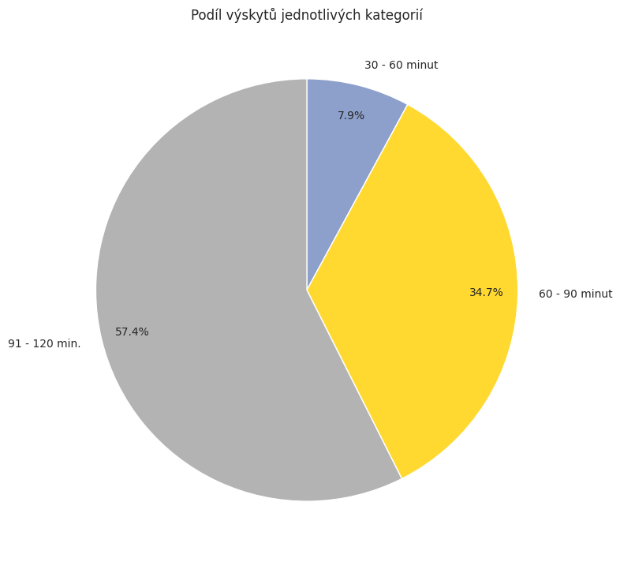

```python
# Vykreslí koláčový graf
fig, ax = plt.subplots(figsize=(8, 8))
kategorie['podil'].plot(
    kind='pie',
    labels=kategorie['kategorie'],
    autopct=lambda pct: f"{pct:.1f}%" if pct > 0 else "",
    startangle=90,
    counterclock=False,
    ax=ax,
    cmap="Set2",
    pctdistance = 0.85
)
ax.set_ylabel('')  # odstraní popisek osy y
ax.set_title('Podíl výskytů jednotlivých kategorií')
plt.tight_layout()
plt.show()
```

```python
lokality_60 = lokality_df[lokality_df["median_casu_cesty"] <= 60]
lokality_60 = lokality_60.sort_values(by="median_casu_cesty")
lokality_60["id"] = lokality_60["id"].astype(int)
lokality_60.info()
lokalita_75 = lokality_df[(lokality_df["median_casu_cesty"] > 60) & (lokality_df["median_casu_cesty"] <= 75)]
lokalita_75 = lokalita_75.sort_values(by="median_casu_cesty")
lokalita_75["id"] = lokalita_75["id"].astype(int)
lokalita_75.info()
lokality_90 = lokality_df[(lokality_df["median_casu_cesty"] > 75) & (lokality_df["median_casu_cesty"] <= 90)]
lokality_90 = lokality_90.sort_values(by="median_casu_cesty")
lokality_90["id"] = lokality_90["id"].astype(int)
lokality_90.info()
lokality_90_plus = lokality_df[lokality_df["median_casu_cesty"] > 90]
lokality_90_plus = lokality_90_plus.sort_values(by="median_casu_cesty")
lokality_90_plus["id"] = lokality_90_plus["id"].astype(int)
lokality_90_plus.info()
```

```
<class 'pandas.core.frame.DataFrame'>
Index: 67 entries, 1170 to 891
Data columns (total 4 columns):
 #   Column             Non-Null Count  Dtype
---  ------             --------------  -----
 0   id                 67 non-null     int64
 1   start              67 non-null     object
 2   median_casu_cesty  67 non-null     float64
 3   kategorie          67 non-null     category
dtypes: category(1), float64(1), int64(1), object(1)
memory usage: 2.4+ KB
<class 'pandas.core.frame.DataFrame'>
Index: 133 entries, 278 to 281
Data columns (total 4 columns):
 #   Column             Non-Null Count  Dtype
---  ------             --------------  -----
 0   id                 133 non-null    int64
 1   start              133 non-null    object
 2   median_casu_cesty  133 non-null    float64
 3   kategorie          133 non-null    category
dtypes: category(1), float64(1), int64(1), object(1)
memory usage: 4.5+ KB
<class 'pandas.core.frame.DataFrame'>
Index: 175 entries, 283 to 1240
Data columns (total 4 columns):
 #   Column             Non-Null Count  Dtype
---  ------             --------------  -----
 0   id                 175 non-null    int64
 1   start              175 non-null    object
 2   median_casu_cesty  175 non-null    float64
 3   kategorie          175 non-null    category
dtypes: category(1), float64(1), int64(1), object(1)
memory usage: 5.8+ KB
<class 'pandas.core.frame.DataFrame'>
Index: 512 entries, 788 to 159
Data columns (total 4 columns):
 #   Column             Non-Null Count  Dtype
---  ------             --------------  -----
 0   id                 512 non-null    int64
 1   start              512 non-null    object
 2   median_casu_cesty  512 non-null    float64
 3   kategorie          512 non-null    category
dtypes: category(1), float64(1), int64(1), object(1)
memory usage: 16.7+ KB
```

```python
data_table.enable_dataframe_formatter()
lokality_60
```

|  | id | start | median_casu_cesty | kategorie |
| --- | --- | --- | --- | --- |
| 1170 | 313491 | Sídliště Brněnská | 38.0 | 30 - 60 minut |
| 847 | 162795 | Šlapanice-střed | 43.0 | 30 - 60 minut |
| 893 | 171972 | Tvarožná | 44.0 | 30 - 60 minut |
| 1130 | 312975 | Průmyslový obvod | 46.0 | 30 - 60 minut |
| 1131 | 312983 | Kolonie | 47.0 | 30 - 60 minut |
| ... | ... | ... | ... | ... |
| 803 | 157431 | Střelice | 60.0 | 30 - 60 minut |
| 668 | 125644 | Ponětovice | 60.0 | 30 - 60 minut |
| 1157 | 313360 | Na zahrádkách | 60.0 | 30 - 60 minut |
| 1107 | 304069 | Velké Kamínky | 60.0 | 30 - 60 minut |
| 891 | 171239 | Tučapy | 60.0 | 30 - 60 minut |

67 rows × 4 columns

```python
lokalita_75
```

|  | id | start | median_casu_cesty | kategorie |
| --- | --- | --- | --- | --- |
| 178 | 48844 | Dlouhé louky | 61.0 | 60 - 90 minut |
| 489 | 138924 | Rajhrad | 61.0 | 60 - 90 minut |
| 366 | 98191 | Mokrá | 61.0 | 60 - 90 minut |
| 276 | 77666 | Podlesí | 61.0 | 60 - 90 minut |
| 512 | 141933 | Rousínovec | 61.0 | 60 - 90 minut |
| ... | ... | ... | ... | ... |
| 767 | 304573 | Kozí hory | 75.0 | 60 - 90 minut |
| 569 | 162043 | Šaratice | 75.0 | 60 - 90 minut |
| 600 | 167452 | Pod Klucaninou | 75.0 | 60 - 90 minut |
| 724 | 194603 | Silničná | 75.0 | 60 - 90 minut |
| 181 | 49867 | Hustopeče-střed | 75.0 | 60 - 90 minut |

133 rows × 4 columns

```python
lokality_90
```

|  | id | start | median_casu_cesty | kategorie |
| --- | --- | --- | --- | --- |
| 183 | 49883 | Hradní | 76.0 | 60 - 90 minut |
| 598 | 167436 | Na Mlýniskách | 76.0 | 60 - 90 minut |
| 633 | 177318 | Královopolské Vážany | 76.0 | 60 - 90 minut |
| 599 | 167444 | Červený mlýn | 76.0 | 60 - 90 minut |
| 486 | 138894 | Jestřebí | 76.0 | 60 - 90 minut |
| ... | ... | ... | ... | ... |
| 464 | 126365 | Štěpnice | 90.0 | 60 - 90 minut |
| 70 | 13668 | Průmyslový obvod-východ | 90.0 | 60 - 90 minut |
| 827 | 314765 | U škol | 90.0 | 60 - 90 minut |
| 829 | 314781 | Za poliklinikou | 90.0 | 60 - 90 minut |
| 865 | 325856 | Rovinský Dvůr | 90.0 | 60 - 90 minut |

175 rows × 4 columns

```python
lokality_90_plus
```

|  | id | start | median_casu_cesty | kategorie |
| --- | --- | --- | --- | --- |
| 788 | 154881 | Starovičky | 91.0 | 91 - 120 min. |
| 48 | 7595 | Borkovany | 91.0 | 91 - 120 min. |
| 744 | 143235 | Rudice | 91.0 | 91 - 120 min. |
| 547 | 99180 | Rakšice | 91.0 | 91 - 120 min. |
| 386 | 75086 | Kroužek | 91.0 | 91 - 120 min. |
| ... | ... | ... | ... | ... |
| 1149 | 313165 | Strážnice | 119.0 | 91 - 120 min. |
| 206 | 38784 | Hevlín | 119.0 | 91 - 120 min. |
| 180 | 31763 | Drahonín | 119.0 | 91 - 120 min. |
| 1129 | 304701 | Padělky | 119.0 | 91 - 120 min. |
| 159 | 26417 | Dlouhá Lhota | 119.0 | 91 - 120 min. |

512 rows × 4 columns

```python
data_table.disable_dataframe_formatter
```

```
google.colab.data_table.disable_dataframe_formatter
def disable_dataframe_formatter()
```

```
/usr/local/lib/python3.11/dist-packages/google/colab/data_table.pyRestores the original IPython formatter for Pandas DataFrames.
```

Vizualizace kategorizované dostupnosti na mapě poskytuje detailní prostorový pohled na rozložení lokalit podle mediánového cestovního času do cílových přestupních uzlů v Brně-středu. Tato interaktivní mapa umožňuje uživateli prozkoumat geografické uspořádání oblastí spadajících do jednotlivých definovaných kategorií dostupnosti.

Každá kategorie dostupnosti je na mapě reprezentována specifickou barvou:

- **Lokalita s dostupností do 60 minut:** (modrá barva) - Tyto oblasti představují lokality s nejvyšší úrovní dostupnosti veřejnou dopravou v daném časovém rámci.
- **Lokalita s dostupností od 61 do 75 minut:** (oranžová barva) - Tyto oblasti indikují střední úroveň dostupnosti.
- **Lokalita s dostupností od 76 do 90 minut:** (fialová barva) - Tyto oblasti reprezentují lokality s nižší úrovní dostupnosti.
- **Lokalita s dostupností od 91 do 120 minut:** (tmavě červená barva)

Z vizualizace je patrné, že oblasti s lepší dostupností (modrá a oranžová barva) se koncentrují především v bezprostřední blízkosti Brna a podél hlavních dopravních koridorů. Naopak lokality s nižší dostupností (fialová a tmavě červená barva) se častěji vyskytují na okrajích kraje a v oblastech s řidším pokrytím veřejnou dopravou.

```python
gpd_lokality_60 = gpd.GeoDataFrame(
    lokality_60,
    geometry=median_cesta_prac_den.geometry
)

gpd_lokality_75 = gpd.GeoDataFrame(
    lokalita_75,
    geometry=median_cesta_prac_den.geometry
)

gdp_lokality_90 = gpd.GeoDataFrame(
    lokality_90,
    geometry=median_cesta_prac_den.geometry
)

gpd_lokality_90_plus = gpd.GeoDataFrame(
    lokality_90_plus,
    geometry=median_cesta_prac_den.geometry
)
```

```python
# 1) střed mapy (např. průměrnou pozici vašich dat)
stred = [
    median_cesta_prac_den.geometry.centroid.y.mean(),
    median_cesta_prac_den.geometry.centroid.x.mean()
]

# 2) základ folium mapy s podkladem
m = folium.Map(
    location=stred,
    zoom_start=11,
    tiles="OpenStreetMap",
    attr="OpenStreetMap"
)

# vrstvy administrativních hranic
brno_stred.explore(
    m=m,
    color="red",
    edgecolor="darkred",
    alpha=0.5,
    name="Brno‑střed - cílová destinace"
)

gpd_lokality_60.explore(
    m=m,
    color = "blue",
    alpha = 0.5,
    name='Lokalita s dostupností do 60 minut'
)

gpd_lokality_75.explore(
    m=m,
    color = "orange",
    alpha = 0.5,
    name='Lokalita s dostupností od 61 do 75 minut'
)

gdp_lokality_90.explore(
    m=m,
    color = "purple",
    alpha = 0.5,
    name='Lokalita s dostupností od 76 do 90 minut'
)

gpd_lokality_90_plus.explore(
    m=m,
    color = "darkred",
    alpha = 0.5,
    name='Lokalita s dostupností od 91 do 120 minut'
)

# ovládání vrstev
folium.LayerControl(collapsed=False).add_to(m)

# Zobrazení mapy

m
```

```
Output hidden; open in https://colab.research.google.com to view.
```

```python
output_file = "categorized_heatmap.html"
m.save(output_file)
```

**Závěr**

Tato studie se zaměřila na analýzu dostupnosti veřejné dopravy z obcí Jihomoravského kraje (s vyloučením oblasti Brno-město) do klíčových přestupních uzlů v městské části Brno-střed. Využitím kombinace geografických dat (administrativní hranice, základní sídelní jednotky, budovy), dat veřejné dopravy (GTFS) a nástrojů pro geoprostorovou analýzu (osmnx, r5py, geopandas, folium) byl vytvořen komplexní model pro hodnocení cestovních časů.

Oblasti s nejkratšími mediánovými cestovními časy se lokality koncentrují v bezprostředním okolí Brna a podél hlavních dopravních koridorů, což je v souladu s očekáváními vzhledem k hustotě dopravní sítě a frekvenci spojení v těchto zónách. Naopak, lokality s mediánovým cestovním časem přesahujícím 60 minut, představující dominantní část analyzovaných bodů s nalezeným spojením (více než 90 %), se nacházejí zejména na okrajích kraje a v oblastech s řidší dopravní obsluhou. Pro významný počet původních lokalit (konkrétně pro ty, pro které nebylo možné vypočítat žádnou cestu, tedy 1284 - 887 = 397 lokalit) v rámci definovaných parametrů (maximální cestovní čas 120 minut a časové okno 45 min.), což poukazuje na oblasti s velmi nízkou nebo efektivně nulovou dostupností veřejnou dopravou do centra Brna ve sledovaném časovém rámci.

Vizualizace dostupnosti formou heatmapy a následná kategorizace lokalit do časových pásem dále podtrhuje prostorové vzorce konektivity. Oblasti spadající do kategorie dostupnosti do 60 minut tvoří relativně malou část analyzovaného území, zatímco kategorie s delšími cestovními časy (60-90 minut a 91-120 minut) zahrnují většinu studovaných lokalit, pro které bylo nalezeno spojení. Toto rozdělení je detailně kvantifikováno v tabulce shrnující mediány, minima, maxima a počty lokalit v jednotlivých kategoriích.

**Omezení a Doporučení pro další výzkum:**

Je nezbytné zdůraznit, že prezentovaná analýza je založena na výpočtech pro specifický den a časové okno. Dostupnost veřejnou dopravou se může signifikantně lišit v závislosti na denní době, dni v týdnu (všední den vs. víkend) a sezóně (např. prázdninové jízdní řády). Pro získání robustnějšího a reprezentativnějšího obrazu o dostupnosti by bylo ideální provést sérii výpočtů pro různá časová okna a období.

Dalším omezením je použití centroidů základních sídelních jednotek jako počátečních bodů, ačkoliv byly přichyceny k nejbližším budovám pro zvýšení realističnosti. Detailnější analýza by mohla využít hustotu zalidnění nebo specifické body zájmu (např. školy, pracoviště) jako počáteční body pro přesnější odhad poptávky po dopravě.

Přes uvedená omezení, tato studie poskytuje cenný počáteční pohled na prostorovou distribuci dostupnosti veřejnou dopravou v Jihomoravském kraji. Identifikace oblastí s nízkou dostupností představuje klíčový vstup pro strategické plánování rozvoje veřejné dopravy a infrastruktury s cílem zlepšit konektivitu a soudržnost regionu. Další výzkum by se mohl zaměřit na detailnější analýzu konkrétních lokalit s nízkou dostupností, posouzení dopadu různých dopravních modů (např. integrovaná cyklistická doprava) a modelování dopadu potenciálních zlepšení dopravní sítě.

```python
from google.colab import drive
drive.mount('/content/drive')
```

```python
!jupyter nbconvert --to html "/content/drive/MyDrive/Colab Notebooks/Data_mining/Projekt/travel_times_final_version_google_colab.ipynb"  --template lab
```

```
[NbConvertApp] Converting notebook /content/drive/MyDrive/Colab Notebooks/Data_mining/Projekt/travel_times_final_version_google_colab.ipynb to html
[NbConvertApp] WARNING | Alternative text is missing on 4 image(s).
[NbConvertApp] Writing 3453176 bytes to /content/drive/MyDrive/Colab Notebooks/Data_mining/Projekt/travel_times_final_version_google_colab.html
```